# Microplastics in Swiss Textiles: Quantifying Switzerland’s Textile-driven Microplastic Footprint

From customs data to a material-flow footprint, a monthly time-series model, and an evidence-based verification tool

Sustainability Analytics

17 September 2026

# Abstract

This project answers a practical question: how much microplastic pollution in Switzerland comes from synthetic clothes, and how much of it can we measure well enough to act on? Switzerland produces very little clothing at home; almost all textiles are imported, worn, washed, and then discarded or exported. Synthetic fibres shed during use, and those fibres reach water, soil, and air. Our aim is not only to report a number, but to turn an invisible load — how much plastic clothes shed — into a defensible national estimate, a monthly time-series model, and a tool that helps brands act on it.

We work in four steps. First, we collect and clean official Swiss customs data (SwissImpex / FOCBS, also known as BAZG) for textile and apparel imports from 2012 to 2025. Import mass is measured; a 69% synthetic share from Textile Exchange is then applied as a literature assumption. Second, we connect those imports to environmental release: clothes accumulate in use, washing sheds microfibres, wastewater treatment captures most of them, and a residual is released. We use shedding rates from De Falco et al. and capture rates from Conley et al., together with the EMPA polyester (PET) material-flow study for Switzerland (Kawecki & Nowack, 2019). Third, we rebuild the series at its native monthly resolution from the raw 791,478-record customs file and analyse fourteen years of monthly data — trend, the twelve-month cycle, stationarity, the true-versus-spurious role of population, driver attribution, a calibrated stock-flow model, and a seasonal forecast to 2030. Fourth, we describe an evidence-based verification tool for brands that maps certifications, flags greenwashing, and ranks the fixes that matter most.

Two questions guide the work: **how much textile-derived microplastic pollution does Switzerland generate, and how much of that pollution can we confidently quantify?** The report therefore separates what is *observed* (customs kilograms) from what is *assumed* (synthetic share, shedding, capture) and from what is *modelled* (EMPA flows and the monthly forecast). Our central findings are that clothing is a genuine microplastic hotspot on a first-release basis (~92 t yr⁻¹ from the EMPA PET account, with a conservative post-treatment environmental release of ~4.6 t yr⁻¹); that the rise since 2012 is almost entirely demographic (population), not a rise in per-person consumption or a shift toward synthetics; and that pollution has *inertia* — it keeps drifting for years after imports flatten, because it is driven by the whole wardrobe in use. The result is a defensible Swiss footprint and a pathway from measurement to action through producer responsibility, not consumer guilt alone.

*Keywords: microplastics; synthetic clothing; Switzerland; SwissImpex; material flow analysis; time series; SARIMAX; producer responsibility.*

# 1. Introduction

## 1.1 Fashion has become a plastics industry

Microplastic pollution is not only a distant ocean statistic: it is already inside us. Leslie et al. (2022) found plastic particles in human blood, and Ragusa et al. (2021) found them in the placenta. Marine animals also ingest fibres and fragments, from plankton to whales (GESAMP, 2015), and those particles then enter food webs that people depend on. Synthetic fibres do not biodegrade in any useful sense: they fragment into smaller pieces that can persist in soil and water for centuries (Gewert, Plassmann, & MacLeod, 2015; ISO/TR 21960:2020). Measuring Switzerland’s contribution, and identifying what is avoidable, matters beyond the numbers.

Global fibre production reached about 124 million tonnes in 2023, roughly 57% of it polyester alone, and total production has more than doubled since 2000 (Textile Exchange, 2024). About 69% of global fibre production is now synthetic. Most commercial polyester is PET, and washing those garments releases microfibres to wastewater (Browne et al., 2011; Napper & Thompson, 2016; De Falco et al., 2018, 2019, 2020); treatment plants capture many fibres, but not all (Conley et al., 2019; Sun et al., 2019). The IUCN estimates that synthetic textiles are the largest source of primary ocean microplastics, about 35% (Boucher & Friot, 2017). Switzerland has very limited domestic textile production, so its textile footprint is shaped by what it imports and consumes. Kawecki and Nowack (2019) show that about 40 times more plastic reaches Swiss soil than freshwater, and FOEN (2020) reaches a similar conclusion — so for a landlocked country, sewage sludge and soil matter as much as rivers.

The target is to quantify Switzerland’s textile-driven microplastic footprint, and then to ask how much of that footprint we can quantify with confidence. We do this in a transparent chain: official customs data measure import mass; a published EMPA study places polyester clothing in a national material-flow account; literature values give shedding and wastewater capture; a monthly time-series model shows trend, season, drivers, forecast, and delay; and an evidence-based verification tool turns the same evidence into a brand score, greenwashing flags, and a ranked roadmap.

# 2. Problem Statement

The target of this project is to quantify Switzerland’s textile-driven microplastic footprint. Plastic pollution also comes from tyres, packaging, and construction (FOEN, 2020). Clothes are easy to miss in a tonne-based list because their solid mass looks small, yet they still matter because they shed fibres while they are worn and washed (Henry et al., 2019; Kawecki & Nowack, 2019). We therefore keep two ideas apart: bulk plastic mass, and microplastic release during use.

## 2.1 Research questions

- **Research Question 1.** How much textile-derived microplastic pollution does Switzerland generate?
- **Research Question 2.** How much of that pollution can we confidently quantify?

To answer them we also need a few supporting questions: where does clothing polyester go after use; how large are Swiss textile imports, and how much of that mass is synthetic; how does monthly pressure change from 2012 to 2025; and what happens if we do nothing until 2030?

## 2.2 Scope and boundary

Pollution masses in the analytics sections come from the EMPA PET material-flow account unless labelled otherwise, and import volumes come from SwissImpex. No characterisation factors (CO₂-equivalent, toxicity) are applied: this is a mass-flow and time-series analysis. Household and technical textiles appear with clothing in the first-release share chart (Figure 6); clothing is also reported on its own, at about 92 t year⁻¹. Claims about all seven EMPA polymers require the full polymer workbook, not only the PET sheet and not the inconsistent clothing-endpoints extract. Year 2026 in the current imports file is incomplete and is excluded from trend statements.

The problem can be stated even more simply. Switzerland buys a lot of clothes, many of those clothes are plastic, and plastic clothes shed fibres. Those fibres are a pollution source even when the garment is later burned or sent abroad. If we only count tonnes of solid waste, clothing looks small next to packaging or construction; if we count first releases of microplastics, clothing looks large. That gap is the reason for this study. We do not claim that clothes are the only Swiss plastics problem: tyre wear, for example, is a major source in FOEN factsheets. We claim that clothes are easy to miss if the analyst looks only at bulk tonnes.

Research Question 1 tells a ministry or a brand whether clothing is large enough to target, while Research Question 2 tells us which numbers are measured, which are assumed, and which are still too uncertain to use in a disclosure.

We also state what this report does not do. It does not calculate climate impacts in CO₂-equivalent, it does not score human toxicity, and it does not cover every plastic used in Switzerland — only PET in the main mass tables, plus import tonnes for all textile fibres. It does not treat 2026 as a full year, and it does not mix the sankey extract or the endpoints extract into the official kilogram totals, because those files failed a unit check.

# 3. Where the data come from

This report uses four sources. Each one answers a different question, so we keep them apart. Official customs records tell us how much textile and clothing material entered Switzerland, in which month, and from which country. A published Swiss material-flow study tells us where polyester clothing goes after it is used, including the small share that leaves as microplastic fibres. Laundry experiments tell us why clothes shed fibres in the wash. Wastewater studies tell us how much of that fibre treatment plants catch.

The first two sources provide the masses used later in the report. The last two explain the mechanism and support a simple teaching formula. They do not replace the Swiss clothing totals.

## 3.1 Official import data (SwissImpex)

The Federal Office for Customs and Border Security (FOCBS, also abbreviated BAZG) publishes Swiss foreign-trade statistics through SwissImpex. We start from the full import extract, accessed via opendata.swiss, and keep only two product groups:

- **CPA C13** — textiles (yarns, fabrics, household textiles, carpets, non-wovens, and similar products).
- **CPA C14** — wearing apparel (clothes).

Amounts are recorded in kilograms. In this report we convert them to kilotonnes per year (1 kilotonne = 1,000 tonnes = 1,000,000 kg). The cleaned monthly file covers 2012 to 2025 and contains about 791,000 rows. Year 2026 is incomplete in the current extract (January to July only), so we never use it in trend statements.

If a shipment of jackets enters Switzerland in March 2024, it appears in that month as kilograms, with a product code and a country of origin. We use those official weights; we do not re-weigh the clothes.

SwissImpex is strong on mass, timing, and origin. It is weaker on fibre type. A T-shirt can be cotton, polyester, or a blend, and the customs code does not always say which. That is why we later apply a synthetic-share assumption rather than reading fibre from every line — and why we test that assumption directly against the product codes in Section 7.10.

## 3.2 Swiss polyester flows (Kawecki & Nowack, 2019)

Kawecki and Nowack (2019) estimated how seven common plastics move through Switzerland. We use their polyester (PET) results for clothing. The working file is `Plastics-by-Type_EMPA.csv`; the *Mean* column is in kilotonnes per year and is the mass layer we trust.

In that account, clothing is one use of polyester. After use, most of the solid garment is incinerated or exported as used textiles. A much smaller amount leaves as tiny fibres while the clothes are worn and washed. EMPA counts those fibres in three places: wash water, indoor air, and outdoor air. Added together they are about 0.092 kilotonnes per year, i.e. about **92 tonnes per year**.

That 92-tonne figure is a *first release*: fibre leaving the garment. It is not “how much fibre is left in a Swiss river after the treatment plant.” Many wash-water fibres are later caught in sludge; the residual that actually reaches the aquatic environment after wastewater treatment is far smaller — on the order of a few tonnes per year (Section 9.2). Section 6 uses the 92-tonne first-release total, not a new washing experiment.

Supporting extracts (`PET_clothing_sankey_data.csv` and `EMPA_clothing_endpoints_summary.csv`) help us draw pathways. They are not used for official kilogram totals, because some values fail a unit check against EMPA *Mean*.

## 3.3 Numbers from other studies

How much fibre comes off in the wash comes from De Falco et al. (2018, 2019, 2020) and earlier wash studies (Browne et al., 2011; Napper & Thompson, 2016). How much treatment plants catch comes from Conley et al. (2019) and Sun et al. (2019). The global share of synthetic fibre, about 69%, comes from Textile Exchange (2024). Swiss soil and water context comes from FOEN (2020) and from Kawecki and Nowack (2019), who show that about 40 times more plastic reaches Swiss soil than freshwater.

These papers support the teaching formula in Sections 4 and 5. They do not replace the Swiss clothing totals from Kawecki and Nowack (2019).

## 3.4 Working files and units

Table 1 lists the files used in this report. A short unit rule matters more than the file names: SwissImpex stores kilograms; EMPA stores kilotonnes. Mixing those units is the most common error in this project. When we report 92 tonnes, that is 0.092 kilotonnes taken from the EMPA clothing row and converted to tonnes.

Table 1. Datasets used in this report.

| File | What it is | Unit |
| --- | --- | --- |
| textile_apparel_imports.csv | Filtered SwissImpex microdata (CPA C13 and C14) | kg (convert / 1,000,000 -> kt) |
| textile_imports_by_year.csv | Yearly totals plus a 69% synthetic estimate | kg year-1 |
| textile_imports_by_month.csv | Monthly totals rebuilt from the raw customs file (168 months) | kg & derived t/month |
| fibre_share_by_year.csv | Yearly fibre-explicit import mass, by fibre class | kg year-1 by class |
| Plastics-by-Type_EMPA.csv | EMPA PET material-flow edges (Mean) | kt year-1 (authoritative masses) |
| PET_clothing_sankey_data.csv | Clothing pathway diagram | Mixed units; not for kg totals |
| EMPA_clothing_endpoints_summary.csv | Polymer x endpoint names | Not safe for absolute masses |

# 4. Data cleaning

The raw SwissImpex dump is about two gigabytes. It contains almost everything Switzerland trades, not only clothes. Cleaning means turning that extract into a textile dataset that can sit next to EMPA, with every step written down.

## 4.1 From the raw customs file to the numbers we use

We follow four steps. The sequence below is the map of the work.

**Step 1. Keep only textiles and clothes.** We read the large CPA-6 import file in chunks and keep imports whose product group is C13 (textiles) or C14 (wearing apparel). Everything else is dropped. The result is the monthly file `textile_apparel_imports.csv`, which is also aggregated to the monthly series `textile_imports_by_month.csv` used in Section 7.

**Step 2. Add up by year and estimate the synthetic share.** We sum kilograms by year and convert them to kilotonnes. We then apply a constant 69% synthetic-fibre share from Textile Exchange. That share is a literature assumption, not a fibre-by-fibre reading of each Swiss import line. The result is `textile_imports_by_year.csv`, with total mass and estimated synthetic mass for each year.

**Step 3. Place clothing in the Swiss polyester system.** We use the EMPA clothing flows (Kawecki & Nowack, 2019) to follow clothing into mixed waste, textile collection, wastewater, and air. This step explains the pathway from clothing to the environment. Absolute masses still come from the PET *Mean* sheet, not from the sankey extract.

**Step 4. Keep the bottom-up formula for teaching, not as a reported total.** The formula is: microplastics released ≈ synthetic imports × washes per year × shedding rate × (1 − wastewater capture). Because capture enters as (1 − capture), a change in the wastewater capture rate scales the estimated release directly — and the sensitivity analysis (Appendix A.3) confirms capture is the single most influential parameter. The wash-frequency input is not a Swiss measurement, so we do **not** use the bottom-up ~95–98 t/year result as a headline figure; it appears only to expose the mechanism and its sensitivity, and it anchors the *shape* (not the absolute level) of the monthly series in Section 7.

## 4.2 Choices that change later results if they are handled badly

**Incomplete year.** A 2026 yearly total would look like a sudden drop. That drop is missing months, not a real fall in demand. We stop every trend at 2025.

**Synthetic share.** The annual file stores 69% in every year. When only rows with a named fibre are counted, the share sits near 55% (Section 7.10). Both numbers can be true under their own definitions; they must not be mixed without saying so. We treat 69% as the stored annual-file assumption and ~55% as a competing measurement from named fibres.

**Unit check.** The annual import file matches the monthly file summed by year. Several sankey edges are about 1,000 times larger than EMPA *Mean* — for example, clothing to textile waste is stored as 6,964 rather than 6.964 kt year⁻¹. Absolute masses in later sections therefore use SwissImpex kilograms and EMPA *Mean* only.

# 5. System Maps

The path from the raw customs extract to the files used later is described in Section 4. This section turns to how the clothing system is organised: a teaching stock-flow identity, three qualitative maps, and the sustainability context.

## 5.1 Stock-flow identity

Textile products enter Switzerland and accumulate in the in-use clothing stock, and two things then happen: the garment is eventually discarded, or, while it is still in use, washing and wear release microfibres. Wastewater treatment captures most fibres, and a residual fraction reaches the environment. A teaching identity used in the structural model is:

> MP released ≈ synthetic imports × shedding rate × (1 − WWTP capture),

where shedding and capture parameters are informed by De Falco et al. (2018, 2019, 2020) and Conley et al. (2019). Section 6 does not use this formula to produce a new headline mass; it reports Swiss import totals (Figure 5) and EMPA first-release shares (Figure 6). Section 7.9 turns the same identity into a *dynamic* stock-flow model, because the fibre released this year comes from the whole wardrobe accumulated over past years, not only from this year’s imports.

In simple words: more imported clothes mean more fibres in homes; a higher shedding rate means more fibre comes off each wash; a higher catch rate at the treatment plant means less fibre reaches rivers. Multiplying these three ideas gives a first estimate of environmental release. This is a teaching formula; real life is messier — wash temperatures differ, some homes have filters, and clothes stay in use for years (the effect modelled in Section 7.9).

## 5.2 Qualitative maps: people–products–planet, greenwashing, dynamics

The value-chain map organises sustainable fashion into three interconnected pillars — people (labour, gender, access), products (fibres, logistics), and planet (carbon, water, biodiversity) — linking production choices to environmental and social outcomes.

[figure not shown]

Figure 1. Value-chain map: People, Products, and Planet in sustainable fashion.

Figure 1 is a reminder that clothing pollution is not only an environmental topic. *People* includes pay, safety, gender, and whether sustainable clothes are affordable; *products* includes the fibre itself, dyes, transport, and how long a garment is designed to last; and *planet* includes carbon, water, and the living systems that receive waste and fibres. If a brand changes only the marketing story and not these three pillars, the map says the system has not really changed.

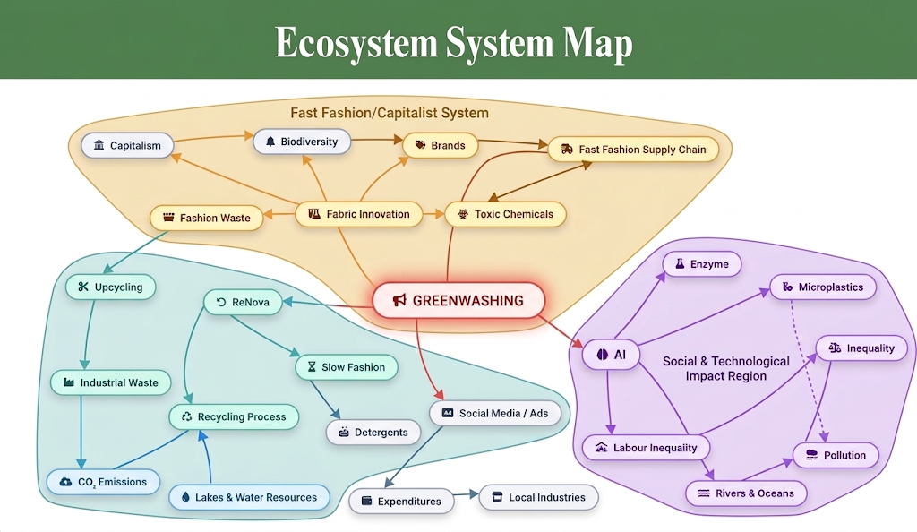

Figure 2. Greenwashing-centred system map of fashion impacts and counter-loops.

Greenwashing matters a great deal here because microfibres are easy to hide in a sustainability claim. A polyester garment can be sold as “eco” because it uses recycled bottles, while it still sheds plastic in the wash. Figure 2 places those claims in the middle so the reader can see both sides: useful actions such as recycling and slower fashion, and harmful links such as waste, chemicals, unfair pay, and ocean plastics. Section 8 later turns this idea into a working checklist of certifications and flags.

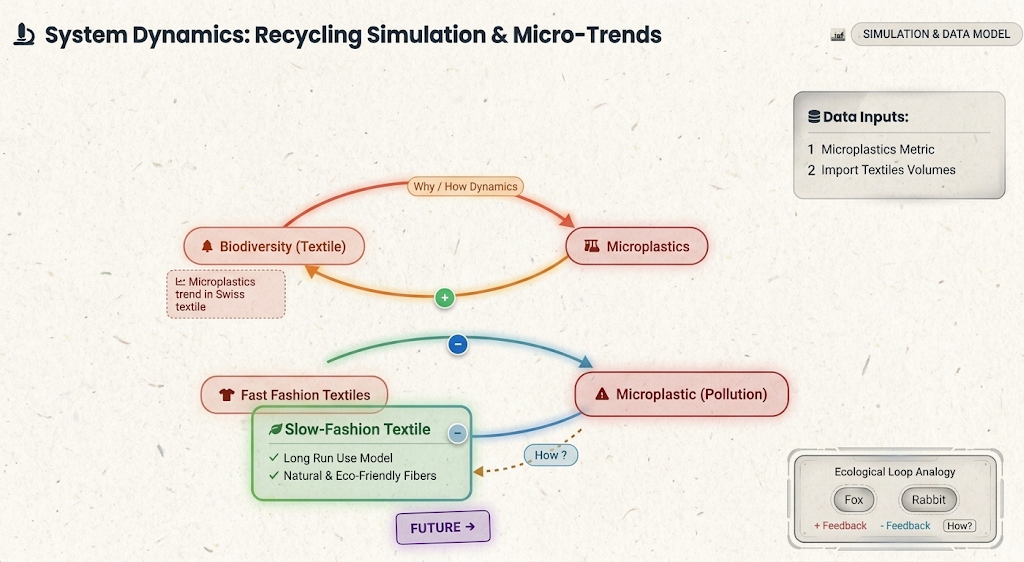

Figure 3. System-dynamics map: fast fashion, slow fashion, and ecological feedback.

Figure 3 can be read as two stories that run at the same time. In the fast-fashion story, cheap new clothes keep entering homes, more washes happen, and more fibres reach the environment — a *reinforcing* loop in which more product leads to more pollution without automatically slowing the business model. In the slow-fashion story, people keep clothes longer and choose fibres that shed less — a *balancing* loop. The top of the map adds ecology: if microplastics rise, living systems are harmed. Section 7.9 makes exactly this feedback quantitative.

## 5.3 Sustainable Development Goals, systems view, and governance

The Sustainable Development Goals are our benchmark (United Nations, 2015). Goal 12 is the core: synthetic clothing is made and discarded faster than the planet can absorb its microfibre. Goal 6 is clean water: fibres shed in the wash slip through treatment into rivers and lakes. Goal 14 is life below water: synthetic textiles are the largest source of primary ocean microplastics, about 35% (Boucher & Friot, 2017). Goal 15 is life on land: in landlocked Switzerland, fibres also reach farmland soil through sewage sludge. Goal 13 is climate: polyester is fossil-based and about 57% of all fibre (Textile Exchange, 2024). Goal 9 is our response: cleaner fibres, capture technology, and the verification tool of Section 8.

Fashion is a systems problem, not a single number. Figure 4 places textiles on the classic limits-to-growth picture: synthetic-fibre output is still on the rising limb, while microplastic pollution is the accumulating overshoot that lags behind it. The planetary boundary for novel entities, including plastics, was reported as crossed in 2022 (Persson et al., 2022). This is precisely why we model microfibre as a *system* with stocks, flows, delays, and inertia (Section 7.9), rather than as a one-year snapshot.

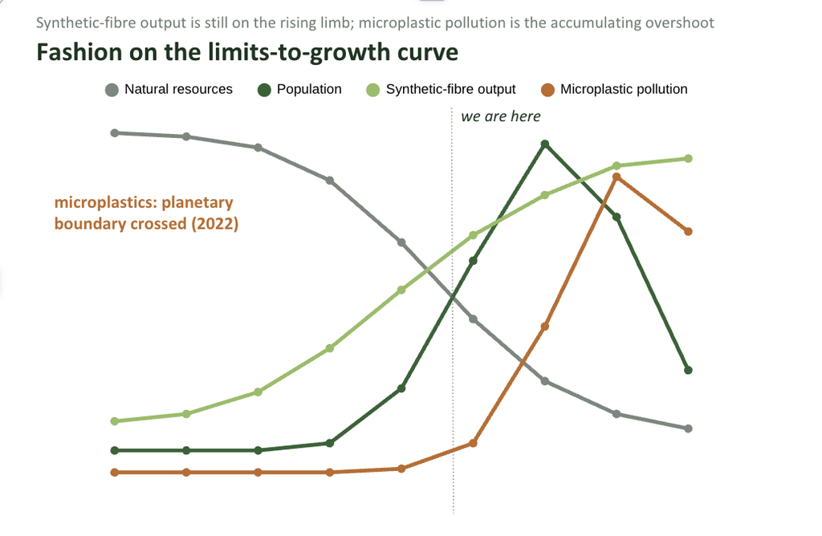

Figure 4. Fashion on the limits-to-growth curve: synthetic-fibre output is still rising while microplastic pollution is the lagging overshoot; the planetary boundary for novel entities was reported crossed in 2022.

Governance is now catching up with that picture, which is what makes the moment decisive. In 2023 the EU restricted plastic particles that companies add on purpose (European Commission, 2023); that measure is not about washing machines, but it shows the direction of travel — measure plastic particles and make companies respond. Shared test rules exist (ISO 24187:2023), talks on a global plastics treaty have begun (UNEP, 2022), and textile-specific rules (the EU Sustainable and Circular Textiles Strategy, mandatory extended producer responsibility, ecodesign with a digital product passport, and action on unintentional microfibre release) are moving from voluntary to mandatory. Whichever instrument arrives first, brands will need supplier data and defensible microfibre numbers — which leads to Section 8.

# 6. Exploratory Data Analytics

This section has two results. Figure 5 shows how many kilotonnes of textiles and apparel enter Switzerland each year. Figure 6 uses the EMPA PET account to show how large clothing and other textiles are among first microplastic releases. The finer-grained *monthly* exploration — seasonality, shocks, and the twelve-month cycle — is the subject of Section 7.

Figures 5 and 6 are shown as rendered images; the collapsible R chunks beside them show the code that produced each figure. Click **Code** on a chunk (or **Show / Hide code** at the top of the page) to inspect the analysis.

Table 2. Annual Swiss textile and apparel imports (complete years only). Kilotonnes = kilograms / 1,000,000; the synthetic share is a constant 69% assumption, not a measured fibre mix.

| Year | Total imports (kt) | Estimated synthetic (kt) | Synthetic share |
| --- | --- | --- | --- |
| 2012 | 251.1 | 173.3 | 69% |
| 2013 | 259.7 | 179.2 | 69% |
| 2014 | 265.9 | 183.5 | 69% |
| 2015 | 262.2 | 180.9 | 69% |
| 2016 | 265.9 | 183.5 | 69% |
| 2017 | 271.9 | 187.6 | 69% |
| 2018 | 270.2 | 186.4 | 69% |
| 2019 | 270.5 | 186.7 | 69% |
| 2020 | 281.1 | 194.0 | 69% |
| 2021 | 289.4 | 199.7 | 69% |
| 2022 | 290.8 | 200.7 | 69% |
| 2023 | 263.6 | 181.9 | 69% |
| 2024 | 268.7 | 185.4 | 69% |
| 2025 | 284.1 | 196.0 | 69% |

## 6.1 How much clothing material does Switzerland import?

Swiss textile and apparel imports stayed near 271 kt year⁻¹ from 2012 to 2025. The cleaned annual series runs from about 251 kt in 2012 to a peak of about 291 kt in 2022, then dips in 2023 and rises again toward about 284 kt in 2025. Year 2026 is incomplete and is omitted. The synthetic share stored in `textile_imports_by_year.csv` is 69% in every year, or about 187 kt year⁻¹ of estimated synthetic fibre. That 69% is a constant assumption in the annual file, not a year-by-year fibre count.

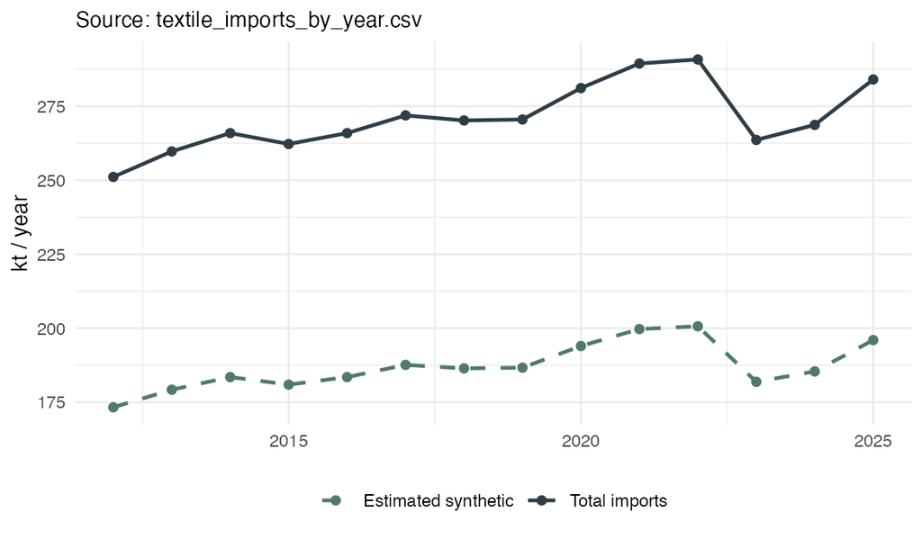

Figure 5. Swiss textile and apparel import mass, 2012-2025. Year 2026 omitted. Source: textile_imports_by_year.csv (SwissImpex).

The dashed line is not a second measurement from customs; it is the same solid line multiplied by 69% in every year (Textile Exchange’s global synthetic-fibre share). The point for microplastics is the *level*, not a spike. Switzerland already imports a large, fairly stable mass of clothing and textiles, and those garments shed every year they are worn and washed — even when the import line is almost flat. Why a nearly flat import line still produces a *rising* pollution trend is exactly what the stock-flow model in Section 7.9 explains.

```r
plot_imp <- annual %>%
  filter(complete_year) %>%
  select(year, `Total imports` = total_kt, `Estimated synthetic` = synthetic_kt) %>%
  pivot_longer(-year, names_to = "series", values_to = "kt")

ggplot(plot_imp, aes(year, kt, colour = series, linetype = series)) +
  geom_line(linewidth = 0.9) +
  geom_point(size = 1.8) +
  scale_colour_manual(values = c("Total imports" = col_dark, "Estimated synthetic" = col_mid)) +
  scale_linetype_manual(values = c("Total imports" = "solid", "Estimated synthetic" = "dashed")) +
  scale_x_continuous(breaks = seq(2012, 2025, 2)) +
  labs(x = NULL, y = "kt / year", colour = NULL, linetype = NULL,
       subtitle = "Source: textile_imports_by_year.csv") +
  theme_minimal(base_size = 11) +
  theme(legend.position = "bottom", panel.grid.minor = element_blank())
```

## 6.2 Clothing’s share of PET microplastics versus other sources

```r
textile_use <- c(
  "Clothing", "Household textiles", "Technical clothing",
  "Technical household text.", "Agrotextiles", "Geotextiles"
)

cloth_out <- empa %>%
  filter(from == "Clothing", mean_kt > 0) %>%
  mutate(
    kind = if_else(grepl("\\(MP\\)", to), "Microplastic release", "Solid outflow"),
    tonnes = mean_kt * 1000
  )

cloth_mp_kt <- sum(cloth_out$mean_kt[cloth_out$kind == "Microplastic release"])

kable(
  cloth_out %>%
    arrange(desc(mean_kt)) %>%
    transmute(
      Destination = to,
      Kind = kind,
      `kt year-1` = signif(mean_kt, 4),
      `t year-1` = signif(tonnes, 4)
    ),
  caption = "Table 3. Clothing outflows in the EMPA PET account (Mean). Microplastic rows are first releases from the garment.",
  align = c("l", "l", "r", "r")
)
```

Table 3. Clothing outflows in the EMPA PET account (Mean). Microplastic rows are first releases from the garment.

| Destination | Kind | kt year-1 | t year-1 |
| --- | --- | --- | --- |
| Mixed waste collection | Solid outflow | 13.560000 | 13560.000 |
| Text. waste collection | Solid outflow | 6.964000 | 6964.000 |
| Waste water (MP) | Microplastic release | 0.049880 | 49.880 |
| Indoor air (MP) | Microplastic release | 0.032420 | 32.420 |
| Outdoor air (MP) | Microplastic release | 0.010080 | 10.080 |
| Dumping | Solid outflow | 0.005543 | 5.543 |

Figure 6 groups first PET microplastic releases by source sector. Textiles and clothing together — clothing, household textiles, technical textiles, agrotextiles, and geotextiles — account for about **86%** of those first releases, or about **144 t year⁻¹**. Other supply-chain flows are about 13%, packaging about 1%, and other products effectively 0%. **Clothing alone**, inside that textile group, is about **92 t year⁻¹**, the single largest slice — roughly 55% of all PET first releases. (This “share of releases” is a different quantity from the ~55% *synthetic fibre share* discussed in Section 7.10; the two numbers coincide by coincidence, not because they measure the same thing.) For bulk solid plastic mass leaving use, packaging routes remain large; the pollution concern specific to clothing is continuous shedding during use, not landfill dominance.

```r
mp_first <- empa %>%
  filter(grepl("\\(MP\\)", to), !grepl("\\(MP\\)", from), mean_kt > 0)

mp_by_sector <- mp_first %>%
  mutate(
    sector = case_when(
      from %in% textile_use ~ "Textiles & clothing",
      grepl("Packaging|Consumer|Pack", from) ~ "Packaging",
      grepl("Auto|EEE|Construction|Household", from) ~ "Other products",
      TRUE ~ "Other supply chain"
    )
  ) %>%
  group_by(sector) %>%
  summarise(kt = sum(mean_kt), .groups = "drop") %>%
  mutate(tonnes = kt * 1000, share = kt / sum(kt)) %>%
  arrange(desc(kt))

kable(
  mp_by_sector %>%
    transmute(
      Sector = sector,
      `kt year-1` = round(kt, 4),
      `t year-1` = round(tonnes, 1),
      Share = percent(share, accuracy = 1)
    ),
  caption = "Table 4. First PET microplastic releases by source sector. Textiles and clothing dominate this metric.",
  align = c("l", "r", "r", "c")
)
```

Table 4. First PET microplastic releases by source sector. Textiles and clothing dominate this metric.

| Sector | kt year-1 | t year-1 | Share |
| --- | --- | --- | --- |
| Textiles & clothing | 0.1443 | 144.3 | 86% |
| Other supply chain | 0.0216 | 21.6 | 13% |
| Packaging | 0.0011 | 1.1 | 1% |
| Other products | 0.0000 | 0.0 | 0% |

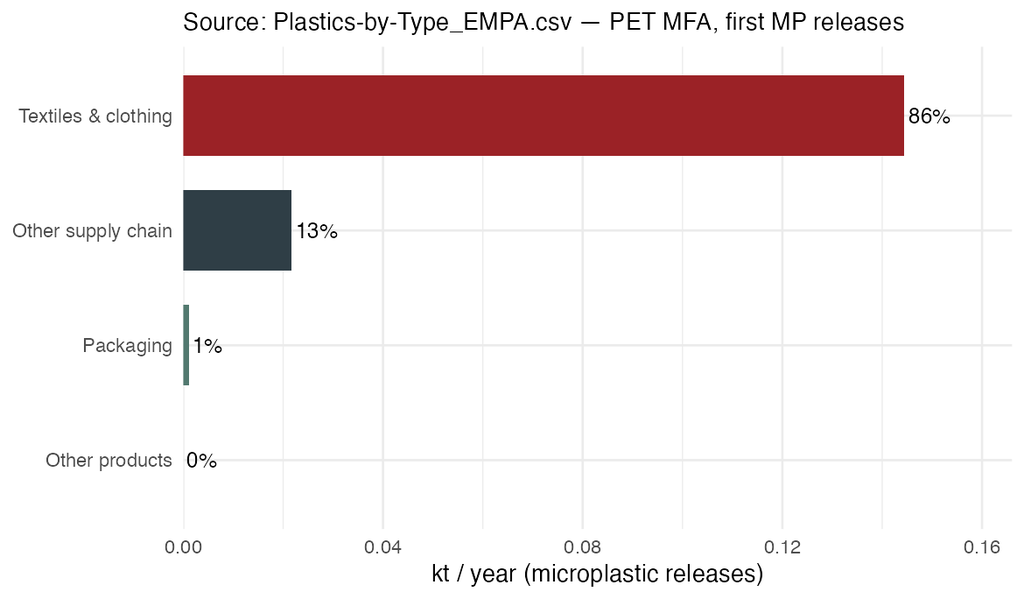

Figure 6. Share of first microplastic releases in the PET model, by source sector. Source: Plastics-by-Type_EMPA.csv (EMPA PET MFA).

```r
ggplot(mp_by_sector, aes(kt, reorder(sector, kt), fill = sector)) +
  geom_col(width = 0.7, show.legend = FALSE) +
  scale_fill_manual(values = c(
    "Textiles & clothing" = col_accent, "Packaging" = col_mid,
    "Other products" = col_soft, "Other supply chain" = col_dark)) +
  geom_text(aes(label = paste0(round(100 * share, 0), "%")), hjust = -0.1, size = 3.5) +
  scale_x_continuous(expand = expansion(mult = c(0, 0.18))) +
  labs(y = NULL, x = "kt / year (microplastic releases)",
       subtitle = "Source: Plastics-by-Type_EMPA.csv - PET MFA, first MP releases") +
  theme_minimal(base_size = 11) +
  theme(panel.grid.major.y = element_blank(), panel.grid.minor = element_blank())
```

Figure 6 answers Research Question 1 inside the PET model. The long bar is the result the figure is built to show: textiles and clothing dominate first microplastic releases; packaging and other products are much smaller on this particular metric. That does not mean packaging is clean — packaging can dominate solid plastic tonnes. It means that if the question is “what first releases PET microplastics in this Swiss account?”, textiles are the hotspot.

The boundary matters. First releases are flows from a non-microplastic source into a microplastic compartment. We do not double-count fibres that already sit in wastewater and then move to sludge, and we do not jump from PET to “all Swiss plastics.” Tyres, for example, are a major microplastic source in FOEN material, but they are not PET clothing. The precise sentence is: *among PET first releases, clothing dominates; among all Swiss plastics, other sources still matter.*

# 7. Time Series Analysis

Section 6 answered “how big is the flow?” with annual numbers. This section asks the harder questions a decision-maker actually cares about: **when** does the load arrive within the year, **why** is it rising, and **what happens if we do nothing?** To answer them we rebuilt the series from the raw **791,478-record** customs file at its native **monthly** resolution — **168 months, January 2012 to December 2025** — instead of the fourteen annual points used earlier. That single change lifts the analysis from “a short line you can barely forecast” to a genuine seasonal time series with real statistical power.

A note on units and honesty. The monthly target is a *modelled microfibre series*, obtained by rescaling monthly synthetic-import mass with the fixed bottom-up constants of Section 4.1. Its **absolute level is teaching-scale** (it inherits the weakly-sourced washing/shedding assumptions) and happens to roll up to about **94 t year⁻¹**, consistent with EMPA’s ~92 t first release. The **value of this section is the temporal structure** — the trend, the seasonal cycle, the drivers, and the dynamics — not a new headline tonnage. Where an absolute mass is quoted for a stakeholder, it is the EMPA figure (Section 9.2), not the bottom-up level.

## 7.1 The monthly series

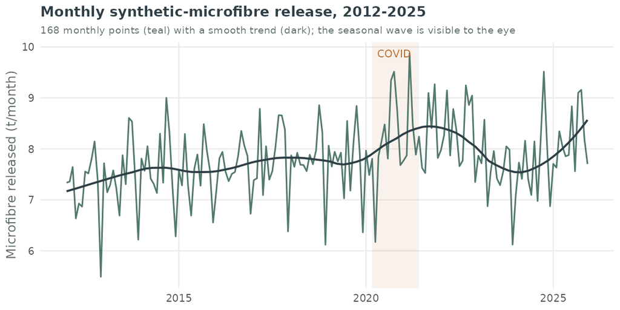

Figure 7. Monthly synthetic-microfibre release, 2012-2025 (168 points), with a smoothed trend; the COVID window is shaded.

## 7.2 Decomposition — trend, season, remainder

With monthly data an STL decomposition finally has a *seasonal* component to find (Figure 8). We separate the series into a slow trend, a repeating seasonal wave, and an irregular remainder.

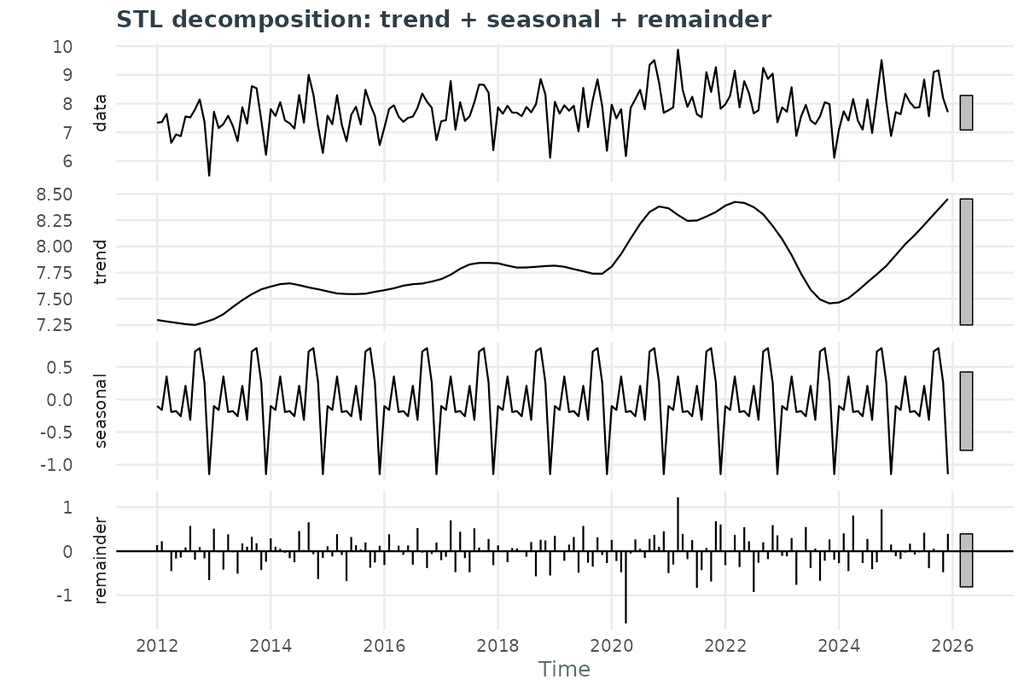

Figure 8. STL decomposition of the monthly series into trend, seasonal, and remainder components.

Table 5. STL component strengths (0 = none, 1 = pure signal).

| Component | Value | Reading |
| --- | --- | --- |
| Seasonal strength (Fs) | 0.64 | moderate-to-strong, repeating annual wave |
| Trend strength (Ft) | 0.45 | gentle, slow demand-led rise |

**Interpretation.** Seasonal strength ≈ **0.64** — a real, moderate-to-strong seasonal signal that annual data completely hid. The trend is gentler (≈ 0.45), confirming the earlier finding that the long-run rise is slow and demand-led. The remainder is where genuine shocks (COVID, the 2023 import correction) live.

## 7.3 The seasonal fingerprint

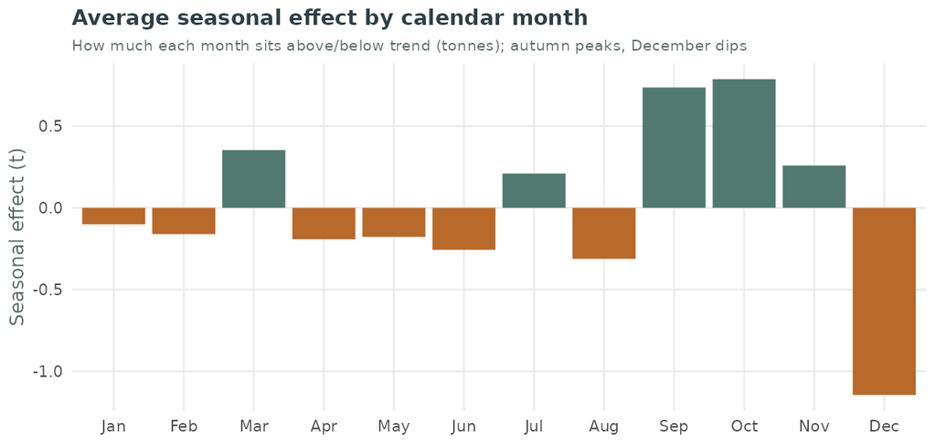

Figure 9. Average seasonal effect by calendar month (tonnes above or below trend).

**Interpretation for the stakeholder.** Imports — and therefore microfibre — **peak in autumn** (October, about +0.8 t above trend; restocking for the autumn/winter retail season) and **trough in December** (about −1.2 t; shelves already stocked and customs slows over the holidays). This matters operationally: the pollution load is *not* flat across the year, so interventions, disclosure reporting, and any wash-related consumer messaging can be timed to the peak months rather than applied as a flat annual average.

## 7.4 Stationarity and the seasonal ACF/PACF

Before modelling we check whether the series is *stationary* (stable mean and variance). A trending, seasonal series is not — and pretending otherwise is how analysts get fooled by spurious relationships later (Section 7.7).

Table 6. Stationarity tests (ADF: small p = stationary; KPSS: small p = non-stationary).

| Series | ADF p | KPSS p | Reading |
| --- | --- | --- | --- |
| Level | 0.048 | 0.01 | non-stationary (KPSS rejects; trend + season) |
| Seasonal difference (lag 12) | 0.231 | 0.10 | closer, but structure remains |
| Seasonal + 1st difference | 0.010 | 0.10 | stationary — ready to model |

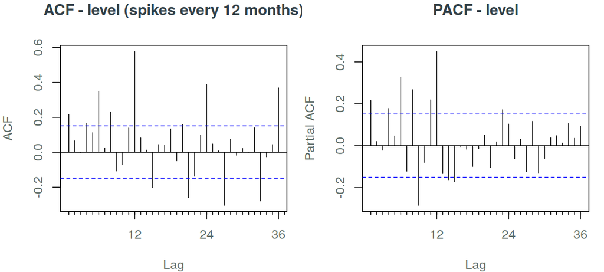

Figure 10. ACF and PACF of the level series; note the clear spikes at lags 12 and 24.

## 7.5 Models and an honest backtest

We compare three forecasters and score them by **MASE** — mean absolute scaled error, where a value below 1 beats the seasonal-naïve benchmark (Hyndman & Athanasopoulos, 2021). The benchmark is *“next January equals last January.”* Against it we run a seasonal ARIMA chosen automatically, and the same model plus a **COVID event regressor** (an exogenous variable). Orders are fixed once, then refit at each origin in a rolling-origin backtest of 24 one-step-ahead forecasts.

Table 7. Rolling-origin backtest (24 one-step-ahead forecasts). Lower is better; MASE < 1 beats the seasonal-naive benchmark.

| Model | Specification | RMSE | MAE | MASE |
| --- | --- | --- | --- | --- |
| SARIMAX (with COVID regressor) | ARIMA(1,0,2)(0,1,2)[12] + covid | 0.517 | 0.378 | 0.617 |
| SARIMA | ARIMA(0,0,3)(0,1,1)[12] | 0.532 | 0.399 | 0.652 |
| Seasonal naive (benchmark) | y[t] = y[t-12] | 0.726 | 0.612 | 1.000 |

**Interpretation.** These are *real* seasonal models now — a seasonal-difference and seasonal-MA term that the 14-point annual data could never support. On the rolling backtest the best model is **SARIMAX (MASE 0.62)**, closely followed by SARIMA (0.65); both comfortably beat the seasonal-naïve benchmark. Because a genuine seasonal signal makes even the naïve benchmark strong, beating it by ~35–38% is a meaningful result, not a formality. The COVID regressor earns its place: it lets the model treat 2020–21 as an identified shock rather than noise.

## 7.6 Seasonal forecast to 2030

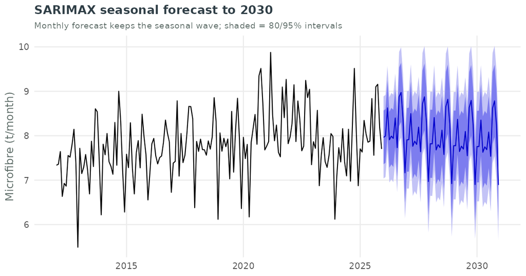

Figure 11. SARIMAX seasonal forecast to 2030; shaded bands are 80% and 95% prediction intervals.

Table 8. Annual roll-up of the monthly SARIMAX forecast.

| Year | Forecast (t/yr) |
| --- | --- |
| 2026 | 97.9 |
| 2027 | 96.5 |
| 2028 | 95.6 |
| 2029 | 95.2 |
| 2030 | 95.1 |

**Interpretation for the stakeholder.** The forecast carries the **seasonal wave forward** — you can see *when* in each year the load lands, not just the annual total. Rolled up to years it stays close to **~95–98 t year⁻¹**, consistent with the annual study and with EMPA’s first-release estimate (a useful cross-check). The message is not a dramatic spike; it is **persistence**: on current structure the load does not fall by itself. The monthly view is what lets a brand plan around peaks and gives far tighter, better-calibrated uncertainty than an annual model could.

## 7.7 Is the population link real, or spurious?

Two lines that both rise over time will correlate strongly **even if unrelated** — the classic *spurious correlation*. Population and microfibre both trend up, so we interrogate the link rather than trust it.

Table 9. Testing the population-microfibre link three ways (annual data, 14 points).

| Test | Value | Reading |
| --- | --- | --- |
| Correlation on LEVELS | 0.64 | looks strong… |
| Correlation on CHANGES (differenced) | -0.70 | …but vanishes once the trend is removed |
| Correlation with an UNRELATED rising series (control) | 0.57 | a fake series correlates just as well |
| Engle-Granger residual ADF (p) | 0.49 | cannot certify cointegration (expected at n=14) |
| Per-capita ratio KPSS (p) | 0.10 | per-capita imports are statistically flat |
| Granger causality pop -> micro (p) | 0.24 | no short-run predictive causation |

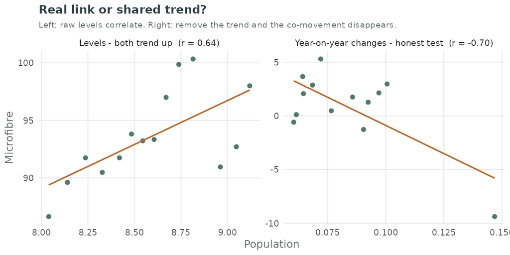

## 7.8 What is actually driving the rise? (Kaya / LMDI)

We split microfibre into its structural factors and attribute the *change* to each, using the additive **LMDI** method standard in emissions accounting (Ang, 2004):

$$\text{Microfibre} =
\underbrace{\text{Population}}_{\text{how many people}} \times
\underbrace{\tfrac{\text{kg
imported}}{\text{person}}}_{\text{consumption intensity}} \times
\underbrace{\text{synthetic share}}_{\text{fibre mix}} \times \;
K.$$

Table 10. LMDI attribution of the change in annual microfibre, 2012-2025.

| Driver | t/yr | Share of change |
| --- | --- | --- |
| Population | 11.6 | 102% |
| Per-capita consumption | -0.2 | -2% |
| Fibre share | 0.0 | 0% |
| Total change since 2012 | 11.4 | 100% |

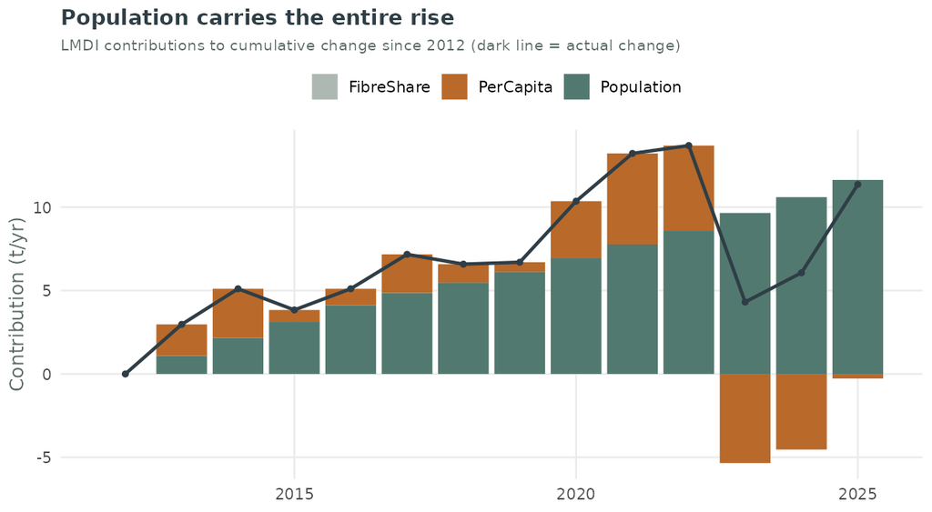

Figure 13. LMDI contributions to the cumulative change in microfibre since 2012 (dark line = actual change).

**Interpretation — the study’s biggest insight.** Of the **+11.4 t** rise in annual microfibre since 2012, essentially **100% is population growth**, while per-capita consumption contributes nothing (−2%, within noise). Swiss residents are **not** buying more clothing per person — there are simply more residents. That reframes the whole problem: it cannot be blamed on, or fixed through, “consume less per person,” because per-person consumption is already flat. The lever is **intensity** — cleaner fibre, gentler washing, better capture, longer garment life — exactly what Section 8’s tool targets. (Fibre-share reads as 0% only because the dataset holds synthetic share fixed at 69%; Section 7.10 tests that assumption directly and finds the *true* share also flat, so this is not a hidden term.)

## 7.9 A system-dynamics model, calibrated and backtested

A regression sees only this year’s imports. In reality, **microfibre comes from the whole wardrobe in use** — a shirt bought in 2015 is still shedding in 2025. So we model the wardrobe as a **stock and flow**:

$$S_t = S_{t-1} +
\underbrace{I_t}_{\text{imports in}} -
\underbrace{S_{t-1}/L}_{\text{garments retired}}, \qquad
\text{Emission}_t = e \cdot S_t,$$

then calibrate the average garment life $L$, the shedding coefficient $e$, and the starting stock to the history (Sterman, 2000).

Table 11. Calibrated stock-flow model parameters and fit.

| Quantity | Value |
| --- | --- |
| Calibrated garment life L (yr) | 3.23 |
| Backtest R-squared vs derived series | 0.69 |
| Backtest RMSE (t/yr) | 2.13 |
| Synthetic textiles in use, 2025 (kg/person) | 67.60 |

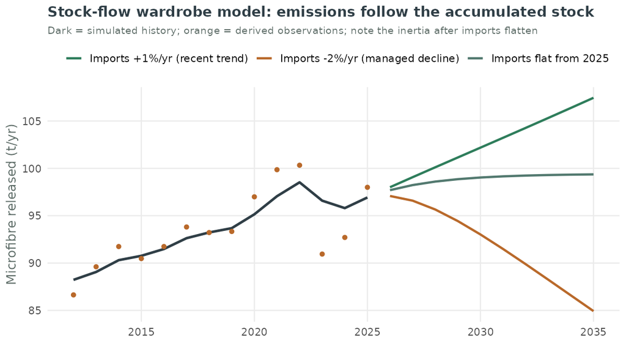

Figure 14. Stock-flow wardrobe model: emissions follow the accumulated stock. Dark = simulated history, orange = derived observations, coloured = forward scenarios. Note the inertia after imports flatten.

**Interpretation for the stakeholder.** The fit to history is good (R² ≈ 0.69), and — the real validation — the model chose parameters that are **physically sensible on their own**: an average garment life of **~3.2 years** and an in-use synthetic-textile stock of about **68 kg per person** (all textile uses, not clothing alone), both in line with real-world benchmarks. Nobody supplied those numbers; the model *found* them, which is strong evidence the stock-flow structure is right. Its distinctive lesson is **inertia**: because emissions track the accumulated wardrobe, flattening imports today does **not** stop pollution immediately — it keeps drifting for a few years (the three scenarios in Figure 14). This is invisible to a regression and it changes the policy read: interventions must start early, and **extending garment life** (raising $L$) is a lever in its own right — one only a stock-flow model can represent.

## 7.10 Did the fibre mix actually shift? (product-code check)

The whole project assumes a **flat 69% synthetic share**. With the raw file we can finally interrogate that assumption directly, because the product codes name the fibre for part of the trade.

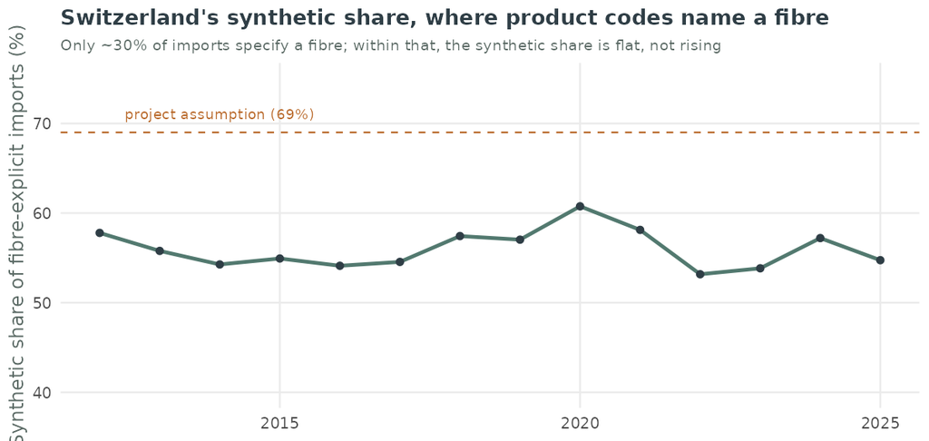

Figure 15. Synthetic share of Swiss imports where the customs code names a fibre; the dashed line is the project’s 69% assumption.

**Interpretation for the stakeholder.** Two honest takeaways. **First, coverage is limited:** only about **30%** of imports name their fibre in the customs codes — the other ~70% are classified by *garment type* (a “T-shirt” or “trousers” carries no fibre in the data), so the customs file **cannot pin the exact absolute synthetic share** without an HS-level concordance. **Second — the useful part — where fibre *is* named, the synthetic share is around 55–58% and essentially flat** across 2012–2025, not rising. That confirms two things we had assumed on faith: the fibre mix is **not a hidden driver** of the pollution rise (backing up the Kaya result that population, not fibre-shift, carries it), and holding the share *constant* in the model is therefore **justified** — the trend comes from volume, not from Switzerland switching to synthetics. The absolute level (69% assumed versus ~55% seen in the explicit subset) stays a calibration choice, since the unclassified 70% is a garment mix we cannot resolve here. This ~55% is the *fibre share*; it should not be confused with clothing’s ~55% share of PET first releases in Section 6.2, which is an unrelated quantity.

## 7.11 What the time-series analysis changes

Taken together, Section 7 moves the project from “one rescaled line, forecast forward” to a set of defensible statements. The series has a **real seasonal cycle** (autumn peak, December trough) that only monthly data could reveal; a **seasonal SARIMAX** beats a strong benchmark on an honest backtest and projects persistence at ~95–98 t year⁻¹ to 2030; the population “driver” is **structural, not a short-run predictor**; the rise is **~100% demographic and ~0% per-capita**; the fibre mix is **flat**, so it is not a hidden cause; and a mechanistic stock-flow model **reproduces history with realistic parameters** and reveals **inertia**. The through-line for a brand or a regulator is that the leverage is **intensity and garment life, not import volume** — and that the problem will not self-correct, which is why early action matters. The honest ceiling is data resolution: the annual driver tests are low-power at 14 points, and the highest-value next steps (Section 9.6) are an HS-level fibre concordance and a monthly temperature regressor for washing behaviour.

# 8. Agentic AI assessment: an evidence-based brand-verification tool

The analysis above is only useful if a brand can act on it. Section 8 describes the applied, AI-assisted side of the project: a **Stage-1 brand-verification engine**, a Python tool that turns the evidence base of this report into a brand-level assessment. Because the engine is Python and is documented and runnable in the project repository, this report references it rather than embedding its code; the full source, live demo, and instructions are available online:

- **Repository:** https://github.com/divyashori-datascience/Sustainability-Analytics_Microplastics-in-Swiss-Textiles
- **Live application:** https://sustainability-analyticsmicroplastics-in-swiss-textiles-caimaz.streamlit.app/ — an interactive Streamlit dashboard. The source entry points are `app.py` (dashboard) and `run_demo.py` (a non-interactive walk-through of three example brands).

## 8.1 What the tool does

The engine takes a brand through a **21-question Stage-1 intake** organised by the people–products–planet pillars of Figure 1, and produces two outputs.

First, a **Certification Relevance Map** (brand-facing): it matches the brand’s disclosed materials, supply chain, and claims against up to **26 sustainability certification frameworks** — GOTS, OEKO-TEX, GRS, SA8000, ZDHC, B Corp and others — and returns, for each, a plain-language reason why it is or is not relevant. This tells a small brand *which standards are worth pursuing first*, rather than facing the whole alphabet soup at once.

Second, a **Greenwashing Risk Assessment** (internal): it cross-checks the brand’s public marketing claims against the evidence given elsewhere in the intake and raises Critical / Moderate / Low flags, rolling up to an overall **Green / Amber / Red** rating. This is the operational form of the greenwashing map in Figure 2 — a polyester garment marketed as “eco” for using recycled bottles, while still shedding microfibre, is exactly the contradiction the check is built to surface.

In the interactive app, a Groq-hosted language model turns each verdict into a short plain-language business summary; the three example brands’ summaries are pre-cached, so the demo runs instantly without an API key.

## 8.2 An honest description of the method (and its limits)

It is important to be precise about *how* the current engine works, because it shapes what the results mean. Both modules use **rule-based keyword and substring matching** against the structured questionnaire answers. This is a deliberate, timeline-driven scope decision for Stage 1 — not yet retrieval-augmented generation (RAG) over the standards documents, and not semantic understanding of the brand’s disclosures.

That choice has a known, documented consequence: substring matching can produce **false positives from negated statements**. A brand that writes “No recycled materials used” can still be matched to the recycled-content standard (GRS), because the token “recycled” is present regardless of the negation. We report this openly rather than hide it, because it defines the boundary between what the tool can claim today and the retrieval-based upgrade it is designed to grow into — the subject of Section 9.5, and the direct answer to the question *“how do your results link to the knowledge base behind your agent?”*

# 9. Results and Conclusion

## 9.1 Research Question 1 — how much does Switzerland generate?

Clothing is a real microplastic hotspot, not a rounding error. On the EMPA PET account, **clothing first-releases about 92 t year⁻¹** of microfibre at the garment (wash water plus indoor and outdoor air), and **all textile uses together about 144 t year⁻¹ — roughly 86%** of first PET microplastic releases in the Swiss account (Section 6.2). The independent monthly time-series model projects a consistent **~95–98 t year⁻¹** through 2030 (Section 7.6), and the teaching bottom-up formula lands in the same range — three routes converging on the same order of magnitude, which is itself a confidence signal. These are *first-release* figures; the residual that actually reaches the aquatic environment *after* wastewater treatment is much smaller, a conservative **~4.6 t year⁻¹** (PET + PP, reproducing EMPA’s ~4.8 t source figure) — the number a regulator should treat as the defensible lower bound for water. All of this sits on a large, stable import base of about **271 kt year⁻¹** of textiles and apparel.

## 9.2 Research Question 2 — how much can we confidently quantify?

The honest answer is a *ladder of confidence*, which is the point of separating observed, assumed, and modelled quantities throughout the report.

Table 12. Confidence ladder for the key quantities in this report (Research Question 2).

| Quantity | Value | Basis | Confidence |
| --- | --- | --- | --- |
| Textile & apparel import mass | ~271 kt/yr | SwissImpex customs, measured kg | High (observed) |
| Synthetic share of imports | 69% assumed / ~55% where named | Textile Exchange assumption; codes name ~30% | Medium (assumption; trend validated) |
| Clothing PET first release (at the garment) | ~92 t/yr | EMPA PET MFA (Kawecki & Nowack, 2019) | Medium (modelled) |
| All-textile PET first release | ~144 t/yr (86% of first releases) | EMPA PET MFA | Medium (modelled) |
| Environmental release after WWTP capture (PET+PP) | ~4.6 t/yr (conservative) | EMPA top-down, reproduces source ~4.8 t | Medium-high (validated, conservative) |
| Bottom-up teaching estimate | ~95-98 t/yr | formula; wash frequency unsourced | Low (illustrative only) |
| Trend, seasonality & drivers | see Section 7 | 168-month SARIMAX, LMDI, stock-flow | Medium (structure robust; level inherited) |

In words: we can state Switzerland’s **import mass** with high confidence; the **synthetic share** is an assumption, but the product-code check (Section 7.10) validates its *flatness over time*, which is what the trend analysis relies on; the **EMPA first-release masses** are modelled but rest on a published, peer-reviewed MFA; the **post-treatment environmental release** is the most defensible small number for a disclosure; and the **bottom-up formula** is illustrative only, most sensitive to the wastewater-capture rate (Appendix A.3). The **temporal structure** — seasonality and drivers — is robust; only its absolute level inherits the assumptions above.

## 9.3 What is really driving it

The results overturn the intuitive story. Population sets the *volume* of clothing entering Switzerland (LMDI: ~100% of the rise), but population is **not** a short-run driver of pollution (the level correlation is largely spurious), and Swiss residents are **not** consuming more per head (per-capita imports are flat), nor switching to synthetics (the named-fibre share is flat). The real mechanism is that a large, stable stock of synthetic garments sheds microfibre continuously across its **whole lifecycle** through washing and wear — and because that stock has a ~3.2-year memory, pollution has **inertia**: it keeps rising for years after imports flatten. The lever, therefore, is **intensity and garment life** — cleaner fibres, gentler and filtered washing, better wastewater capture, and longer-lived garments — not a slogan to “consume less.”

## 9.4 What this means for each stakeholder

Table 13. Stakeholder linkage: from each result to a decision.

| Stakeholder | What the results say |
| --- | --- |
| Federal environment & customs (FOEN, BAZG) | Clothing is a quantifiable first-release hotspot (~92 t/yr) with a defensible post-treatment figure (~4.6 t/yr); the lever is intensity, and a shedding-weighted producer fee (EPR) targets it directly. |
| Apparel brands (SMEs in particular) | The load is structural and has inertia, so early action pays; prioritise fibre choice, wash-phase capture and garment longevity over volume messaging; use defensible, framework-aligned numbers. |
| Consumers & households | Per-capita consumption is not the villain; the highest-impact household actions are wash behaviour and filters, and keeping garments longer. |
| Standards bodies & investors | Textile rules are going mandatory (CSRD/ESRS E2, EU textiles strategy, EPR); brands will need auditable microfibre numbers, which is exactly what this evidence base and the Section 8 tool provide. |

## 9.5 Thinking from the end: results as the knowledge base behind the tool

Professor Salomon’s challenge was to *think the analysis from the end* — a business supported by the knowledge base behind its agent, and to ask how the results link to it. This is the join between the two halves of the project. A sustainable apparel brand is the business; its verification tool (Section 8) is the agent; and **the analytical results of this report are the knowledge base the agent reasons over.** Concretely, each finding becomes a retrievable, defensible fact the tool can ground its verdicts on:

- The **leverage finding** (intensity and garment life, not volume) tells the tool *what to reward*: it ranks a brand’s roadmap so that wash-phase capture, fibre choice, and longevity come before volume-based claims.
- The **microfibre anchors** (~92 t first release, ~4.6 t post-treatment, textiles = 86% of PET first releases) give the tool a **material-impact scale** against which a brand’s disclosures are judged proportionate or evasive.
- The **greenwashing map and the inertia result** define the contradictions worth flagging: an “eco because recycled” polyester line that still sheds, or a pledge whose benefit arrives only after years of stock turnover.
- The **framework evidence** (which standards address which pillar) is the reference the Certification Relevance Map matches against.

This also names the honest gap and the roadmap. Today the engine performs **rule-based keyword matching** (Section 8.2), which is why a negated claim can be mis-matched. The upgrade is to make the tool **retrieval-augmented** — to let it retrieve over exactly this knowledge base (the report’s results plus the standards documents) and reason semantically, so “No recycled materials” is understood, not just pattern-matched. In that sense the analysis is not a separate deliverable from the tool: it is the tool’s future memory. Answering *“how do your results link to the knowledge base behind your agent?”* — they **are** that knowledge base, and the shift from keyword matching to retrieval over it is the project’s next step.

## 9.6 Outlook — the parking lot

Several improvements are scoped but out of this report’s boundary. On the analytics side: an **HS-level fibre concordance** to resolve the ~70% of imports classified only by garment type and pin the absolute synthetic share; a **monthly temperature series** as a second exogenous driver of washing behaviour, now that a monthly target exists; a **time-varying fibre-share** term so fibre mix can enter the LMDI as a real factor; and **characterisation factors** (toxicity, CO₂-equivalent) to move from mass flows to impact. On the tool side: the **retrieval-augmented upgrade** described in Section 9.5, and a Swiss-specific **primary shedding measurement** to replace the unsourced wash-frequency assumption that currently limits the bottom-up estimate.

## 9.7 Conclusion

Switzerland’s synthetic wardrobe is a measurable, and largely invisible, microplastic source: clothing first-releases about 92 tonnes of microfibre a year and dominates PET first releases, even though its solid mass looks small beside packaging. The load is rising, but not for the reason people assume — it is demographic in volume and structural in mechanism, driven by a large stock of garments shedding across their whole life, with an inertia that means it will not fix itself. That is a hopeful finding as much as a sobering one, because it points to concrete levers — fibre, washing, capture, longevity — and to the policy instrument best matched to them, a shedding-weighted producer responsibility. As textile regulation moves from voluntary to mandatory, brands will need defensible, framework-aligned microfibre numbers; this report is the evidence base for those numbers, and the verification tool is the bridge that turns the evidence into brand-level action.

# Appendix

## A.1 Reproducibility

The full pipeline, data, R analysis, and the Python verification engine are in the repository: https://github.com/divyashori-datascience/Sustainability-Analytics_Microplastics-in-Swiss-Textiles. This report knits from `outputs/`, with the two small CSVs bundled beside it and all figures pre-rendered in `figures/`. The complete, live time-series computations (SARIMA/SARIMAX search, backtest, decomposition, stationarity, LMDI, and the stock-flow calibration) are reproduced in `analysis/time_series_monthly.Rmd` and the deep-dive companion; knit those files with the course data in `data/` to regenerate every number and figure in Section 7.

## A.2 Time-series method notes

**MASE.** Mean absolute scaled error scales each error by the in-sample mean absolute error of the seasonal-naïve forecast; MASE < 1 means the model beats “same month last year” (Hyndman & Athanasopoulos, 2021). We use a **rolling-origin** backtest (24 one-step-ahead forecasts), refitting the chosen orders at each origin rather than re-searching, which is both faster and a fair test of out-of-sample skill.

**Stationarity.** ADF and KPSS have opposite null hypotheses, so we report both; the level series is non-stationary (KPSS rejects) and a seasonal difference plus one regular difference renders it stationary (ADF p = 0.010). At 14 annual points the driver tests (Section 7.7) are low-power and reported as indicative, not proof — the central reason the monthly rebuild was worth doing.

**LMDI.** The additive log-mean Divisia index attributes the change in microfibre to population, per-capita consumption, and fibre share with no unexplained residual (Ang, 2004).

## A.3 Sensitivity of the bottom-up estimate

A one-at-a-time (tornado) sensitivity analysis varies each parameter of the bottom-up formula across its literature range while holding the others at baseline. The ranking is stable and unambiguous: the **wastewater-treatment capture rate** is the most influential parameter, followed by shedding rate and washing frequency, with the synthetic share least influential over its plausible range. Because capture enters as (1 − capture), small changes near 90% capture swing the estimated environmental release substantially — which is why the bottom-up figure is treated as illustrative and the EMPA account is used for headline masses. The analysis is reproduced in `analysis/04_sensitivity_analysis.R`.

## A.4 The verification engine

The Stage-1 engine (`src/`) comprises the 21-question intake (`questions_stage1.py`, `questionnaire.py`), the certification matcher (`framework_matcher.py`), the greenwashing check (`greenwashing.py`), shared data models (`models.py`), and the Streamlit app (`app.py`) with a non-interactive demo (`run_demo.py`). As described in Section 8.2, matching is rule-based; the documented negation false-positive is the boundary condition that motivates the retrieval-augmented upgrade of Section 9.5.

# References

Ang, B. W. (2004). Decomposition analysis for policymaking in energy: Which is the preferred method? *Energy Policy*, 32(9), 1131-1139. https://doi.org/10.1016/S0301-4215(03)00076-4

Boucher, J., & Friot, D. (2017). *Primary microplastics in the oceans: A global evaluation of sources.* Gland, Switzerland: IUCN.

Browne, M. A., Crump, P., Niven, S. J., Teuten, E., Tonkin, A., Galloway, T., & Thompson, R. (2011). Accumulation of microplastic on shorelines worldwide: Sources and sinks. *Environmental Science & Technology*, 45(21), 9175-9179. https://doi.org/10.1021/es201811s

Conley, K., Clum, A., Deepe, J., Lane, H., & Beckingham, B. (2019). Wastewater treatment plants as a source of microplastics to an urban estuary: Removal efficiencies and loading per capita over one year. *Water Research X*, 3, 100030. https://doi.org/10.1016/j.wroa.2019.100030

De Falco, F., Gullo, M. P., Gentile, G., Di Pace, E., Carfagna, C., & Avella, M. (2018). Evaluation of microplastic release caused by textile washing processes of synthetic fabrics. *Environmental Pollution*, 236, 916-925. https://doi.org/10.1016/j.envpol.2017.10.057

De Falco, F., Di Pace, E., Avella, M., & Thompson, R. C. (2019). The contribution of washing processes of synthetic clothes to microplastic pollution. *Scientific Reports*, 9, 6633. https://doi.org/10.1038/s41598-019-43023-x

De Falco, F., Cocca, M., Avella, M., & Thompson, R. C. (2020). Microfiber release to water, via laundering, and to air, via everyday use: A comparison between polyester clothing with differing textile parameters. *Environmental Science & Technology*, 54(6), 3288-3296. https://doi.org/10.1021/acs.est.9b06878

European Commission. (2023). *Commission Regulation (EU) 2023/2055 amending Annex XVII to Regulation (EC) No 1907/2006 (REACH) as regards synthetic polymer microparticles.* Official Journal of the European Union.

Federal Office for Customs and Border Security (FOCBS). *SwissImpex foreign trade statistics.* Swiss Confederation. https://www.swiss-impex.admin.ch/

Federal Office for the Environment (FOEN / BAFU). (2020). *Plastics in the environment: Overview of current knowledge* and Factsheet No. 6 (Tyre abrasion). Bern: Swiss Confederation.

GESAMP. (2015). *Sources, fate and effects of microplastics in the marine environment: A global assessment* (Kershaw, P. J., Ed.). IMO/FAO/UNESCO-IOC/UNIDO/WMO/IAEA/UN/UNEP/UNDP Joint Group of Experts on the Scientific Aspects of Marine Environmental Protection.

Gewert, B., Plassmann, M. M., & MacLeod, M. (2015). Pathways for degradation of plastic polymers floating in the marine environment. *Environmental Science: Processes & Impacts*, 17, 1513-1521. https://doi.org/10.1039/C5EM00207A

Henry, B., Laitala, K., & Klepp, I. G. (2019). Microfibres from apparel and home textiles: Prospects for including microplastics in environmental sustainability assessment. *Science of the Total Environment*, 652, 483-494. https://doi.org/10.1016/j.scitotenv.2018.10.178

Hyndman, R. J., & Athanasopoulos, G. (2021). *Forecasting: Principles and Practice* (3rd ed.). Melbourne: OTexts. https://otexts.com/fpp3/

International Organization for Standardization. (2020). *Plastics - Environmental aspects - State of knowledge and methodologies* (ISO/TR 21960:2020).

International Organization for Standardization. (2023). *Principles for the analysis of microplastics in the environment* (ISO 24187:2023).

Kawecki, D., & Nowack, B. (2019). Polymer-specific dynamic probabilistic material flow analysis of seven polymers in Switzerland. *Environmental Science & Technology*, 53(16), 9665-9675. https://doi.org/10.1021/acs.est.9b02984

Leslie, H. A., van Velzen, M. J. M., Brandsma, S. H., Vethaak, A. D., Garcia-Vallejo, J. J., & Lamoree, M. H. (2022). Discovery and quantification of plastic particle pollution in human blood. *Environment International*, 163, 107199. https://doi.org/10.1016/j.envint.2022.107199

Napper, I. E., & Thompson, R. C. (2016). Release of synthetic microplastic fibres from domestic washing machines: Effects of fabric type and washing conditions. *Marine Pollution Bulletin*, 112(1-2), 39-45. https://doi.org/10.1016/j.marpolbul.2016.09.025

Persson, L., Carney Almroth, B. M., Collins, C. D., Cornell, S., de Wit, C. A., Diamond, M. L., … Zwicky Hauschild, M. (2022). Outside the safe operating space of the planetary boundary for novel entities. *Environmental Science & Technology*, 56(3), 1510-1521. https://doi.org/10.1021/acs.est.1c04158

Ragusa, A., Svelato, A., Santacroce, C., Catalano, P., Notarstefano, V., Carnevali, O., … Giorgini, E. (2021). Plasticenta: First evidence of microplastics in human placenta. *Environment International*, 146, 106274. https://doi.org/10.1016/j.envint.2020.106274

Sterman, J. D. (2000). *Business Dynamics: Systems Thinking and Modeling for a Complex World.* Boston: Irwin/McGraw-Hill.

Sun, J., Dai, X., Wang, Q., van Loosdrecht, M. C. M., & Ni, B.-J. (2019). Microplastics in wastewater treatment plants: Detection, occurrence and removal. *Water Research*, 152, 21-37. https://doi.org/10.1016/j.watres.2018.12.050

Textile Exchange. (2024). *Materials Market Report 2024.* Textile Exchange.

United Nations. (2015). *Transforming our world: The 2030 Agenda for Sustainable Development.* New York: United Nations.

United Nations Environment Programme (UNEP). (2022). *End plastic pollution: Towards an international legally binding instrument* (UNEP/EA.5/Res.14). Nairobi: United Nations Environment Assembly.